# Multinomial Logistic Regression – Shelter Outcomes

Zhelang (Zilan) Li – W01G04

This is my model section for the group report: multinomial logistic regression (LR), the interpretable linear baseline in our plan. It reuses the group’s shared preprocessing from `STAT5003_group_project_RMarkdown_template_v29.Rmd` without changing it, so the CV folds, train/test split and predictors are identical to everyone else’s. All code is in this file; it knits from the `zilan/` folder of the repo.

## 1. Shared preprocessing (from the group template)

To stay in sync with the group, the template’s code (all chunks up to and including `common-cv-preprocessing`) is extracted with `knitr::purl()` and run here. Its EDA plots are suppressed. This gives the same `train_raw`/`test_raw`, `x_train`, `y_train`, `x_test`, `y_test`, `cv_folds` and `cv_data` (seed 5003, stratified 80/20 split, 5 folds).

```r
repo_dir <- normalizePath("..")
template_file <- file.path(repo_dir, "STAT5003_group_project_RMarkdown_template_v29.Rmd")

purled <- tempfile(fileext = ".R")
invisible(knitr::purl(template_file, output = purled, documentation = 1, quiet = TRUE))
template_code <- readLines(purled)
stop_line <- grep("^## ----fit-multinomial", template_code)[1] - 1
stopifnot(!is.na(stop_line))

old_wd <- setwd(repo_dir)
grDevices::pdf(NULL)                       # swallow the template's EDA plots
invisible(capture.output(
  suppressMessages(eval(parse(text = template_code[1:stop_line]), envir = globalenv()))
))
grDevices::dev.off()
```

```r
setwd(old_wd)

library(dplyr); library(tidyr); library(ggplot2); library(nnet); library(glmnet)
library(splines); library(knitr)
set.seed(5003)
dir.create("results", showWarnings = FALSE)

classes <- levels(y_train)
stopifnot(!anyNA(x_train), !anyNA(x_test))
kable(tibble(Set = c("Latest-intake animals", "Training (80%)", "Test (20%)"),
             n = c(nrow(data_latest), nrow(x_train), nrow(x_test)),
             Animals_shared_with_train = c(NA, NA,
               sum(test_raw$Animal.ID %in% train_raw$Animal.ID))),
      caption = "Shared modelling sample (one record per animal)")
```

Shared modelling sample (one record per animal)

| Set | n | Animals_shared_with_train |
| --- | --- | --- |
| Latest-intake animals | 16831 | NA |
| Training (80%) | 13467 | NA |
| Test (20%) | 3364 | 0 |

The template already keeps one record per animal (latest intake), so no animal can appear in both training and test, or in two CV folds. This deals with the repeated Animal IDs the A1 marker flagged.

## 2. Feature handling for logistic regression

LR is linear in the log-odds, so the factor data from the template need extra work:

- **Encoding:** treatment (dummy) coding learned from the training part only. Reference levels: `Type` = Cat, `Sex` = Female, `has_pattern` = Pure, `has_Name` = 0. For `Spayed.Neutered`, breed group and base colour, the reference is the most common training level, which keeps the coefficient estimates stable.
- **Scaling:** age is standardised with the training mean/SD (glmnet also standardises columns internally, and coefficients are returned on the original scale).
- **Type/Age overlap:** the template already recodes Puppy/Kitten into Dog/Cat, so `Type` is species only and life stage comes from age alone. LR assumes a straight-line effect of age, but the EDA shows age is strongly right-skewed and its effect is not linear. So the extended feature set uses a natural spline on `log1p(age)` (3 df) and a Dog × age interaction (age effects can differ by species). It also adds an `age_missing` flag: imputed ages are otherwise indistinguishable from real ones, and missing DOB is itself informative.
- **Collinearity:** checked with VIFs on the dummy design and Cramér’s V between predictors (below). The elastic-net penalty also stabilises correlated dummies.
- **Class imbalance:** inverse-frequency case weights, $w_c = n / (K n_c)$, from the training part only.

```r
# Metrics used by the whole group: macro-F1 (primary), balanced accuracy, per-class recall.
class_metrics <- function(truth, pred) {
  truth <- factor(truth, levels = classes); pred <- factor(pred, levels = classes)
  cm <- table(Truth = truth, Pred = pred)
  recall <- diag(cm) / rowSums(cm)
  precision <- ifelse(colSums(cm) > 0, diag(cm) / colSums(cm), 0)
  f1 <- ifelse(precision + recall > 0, 2 * precision * recall / (precision + recall), 0)
  list(cm = cm, recall = recall, precision = precision, f1 = f1,
       summary = c(macro_F1 = mean(f1), balanced_accuracy = mean(recall),
                   accuracy = sum(diag(cm)) / sum(cm)))
}

class_weights <- function(y) {
  w <- length(y) / (length(levels(y)) * as.numeric(table(y)))
  setNames(w, levels(y))[as.character(y)]
}

ref_levels <- function(x) {
  fixed <- c(Type = "Cat", Sex = "Female", has_pattern = "Pure", has_Name = "0")
  sapply(names(Filter(is.factor, x)), function(v) {
    if (v %in% names(fixed)) fixed[[v]] else names(which.max(table(x[[v]])))
  })
}

# Build train/new design matrices with rules learned from the training part only.
# spec = "base": shared 8 predictors, linear standardised age.
# spec = "extended": + ns(log1p(age), 3) + Dog x log-age + age_missing flag.
build_design <- function(xtr, xnew, miss_tr, miss_new, spec = "base", drop = character(0)) {
  refs <- ref_levels(xtr)
  prep <- function(x) {
    for (v in names(refs)) x[[v]] <- relevel(factor(x[[v]], levels = levels(xtr[[v]])), refs[[v]])
    x[, setdiff(names(x), c("Age_Years_imputed", drop)), drop = FALSE]
  }
  ftr <- prep(xtr); fnew <- prep(xnew)
  mm <- function(f) model.matrix(~ ., data = f)[, -1, drop = FALSE]
  Xtr <- mm(ftr); Xnew <- mm(fnew)
  mu <- mean(xtr$Age_Years_imputed); s <- sd(xtr$Age_Years_imputed)
  if (spec == "base") {
    Xtr <- cbind(Xtr, age_z = (xtr$Age_Years_imputed - mu) / s)
    Xnew <- cbind(Xnew, age_z = (xnew$Age_Years_imputed - mu) / s)
  } else {
    la_tr <- log1p(xtr$Age_Years_imputed); la_new <- log1p(xnew$Age_Years_imputed)
    basis <- ns(la_tr, df = 3)
    B_tr <- basis; B_new <- predict(basis, la_new)
    colnames(B_tr) <- colnames(B_new) <- paste0("age_ns", 1:3)
    lm_ <- mean(la_tr); ls_ <- sd(la_tr)
    Xtr <- cbind(Xtr, unclass(B_tr)[, 1:3],
                 dog_x_logage = (xtr$Type == "Dog") * (la_tr - lm_) / ls_,
                 age_missing = as.numeric(miss_tr))
    Xnew <- cbind(Xnew, B_new,
                  dog_x_logage = (xnew$Type == "Dog") * (la_new - lm_) / ls_,
                  age_missing = as.numeric(miss_new))
  }
  colnames(Xtr) <- colnames(Xnew) <- make.names(colnames(Xtr))
  # Drop any column that is constant in training (zero variance).
  keep <- apply(Xtr, 2, function(z) length(unique(z)) > 1)
  list(Xtr = Xtr[, keep, drop = FALSE], Xnew = Xnew[, keep, drop = FALSE])
}

# Age missing flag (missing DOB or negative age), aligned to template rows.
miss_train <- is.na(train_raw$Age_Years)
miss_test <- is.na(test_raw$Age_Years)
fold_miss <- lapply(seq_along(cv_folds), function(k) list(
  tr = miss_train[-cv_folds[[k]]], va = miss_train[cv_folds[[k]]]))
for (k in seq_along(cv_data)) {          # check alignment with the template's cv_data
  stopifnot(identical(cv_data[[k]]$y_valid, y_train[cv_folds[[k]]]))
}
```

### Each predictor’s relationship with the outcome (training data)

A1 feedback asked for each predictor to be linked to the outcome. Below, each predictor is tested against `Outcome.Group` on the training set only (χ² test and Cramér’s V for factors; Kruskal–Wallis and ε² for age). The odds ratios in Section 4 give the direction.

```r
assoc <- lapply(names(x_train), function(v) {
  x <- x_train[[v]]
  if (is.factor(x)) {
    tst <- suppressWarnings(chisq.test(table(x, y_train)))
    V <- sqrt(unname(tst$statistic) / (length(x) * (min(nlevels(x), length(classes)) - 1)))
    tibble(Predictor = v, Test = "Chi-squared", Statistic = unname(tst$statistic),
           df = unname(tst$parameter), p_value = tst$p.value, Effect_size = V,
           Effect_measure = "Cramer's V")
  } else {
    tst <- kruskal.test(x ~ y_train)
    tibble(Predictor = v, Test = "Kruskal-Wallis", Statistic = unname(tst$statistic),
           df = unname(tst$parameter), p_value = tst$p.value,
           Effect_size = unname(tst$statistic) / (length(x) - 1), Effect_measure = "epsilon^2")
  }
}) %>% bind_rows() %>% arrange(desc(Effect_size))
write.csv(assoc, "results/feature_outcome_association.csv", row.names = FALSE)
kable(assoc, digits = 3, caption = "Univariate association with Outcome.Group (training set)")
```

Univariate association with Outcome.Group (training set)

| Predictor | Test | Statistic | df | p_value | Effect_size | Effect_measure |
| --- | --- | --- | --- | --- | --- | --- |
| Spayed.Neutered | Chi-squared | 10019.969 | 8 | 0 | 0.610 | Cramer’s V |
| has_Name | Chi-squared | 3562.501 | 4 | 0 | 0.514 | Cramer’s V |
| Sex | Chi-squared | 2433.763 | 8 | 0 | 0.301 | Cramer’s V |
| Type | Chi-squared | 431.162 | 4 | 0 | 0.179 | Cramer’s V |
| primary.breed.group | Chi-squared | 600.182 | 32 | 0 | 0.106 | Cramer’s V |
| Age_Years_imputed | Kruskal-Wallis | 1285.728 | 4 | 0 | 0.095 | epsilon^2 |
| has_pattern | Chi-squared | 111.221 | 4 | 0 | 0.091 | Cramer’s V |
| Base_Color | Chi-squared | 57.871 | 20 | 0 | 0.033 | Cramer’s V |

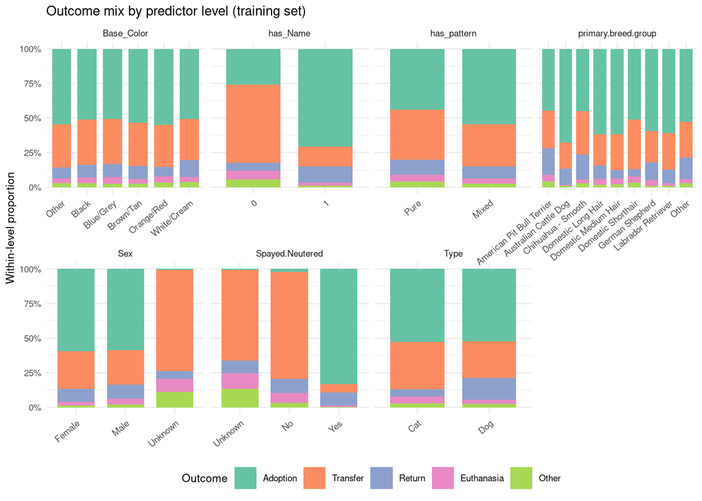

```r
prop_tab <- function(v) {
  as.data.frame(prop.table(table(x_train[[v]], y_train), 1)) %>%
    rename(Level = Var1, Outcome = y_train, Prop = Freq) %>% mutate(Predictor = v)
}
prop_long <- bind_rows(lapply(setdiff(names(x_train), "Age_Years_imputed"), prop_tab))
p_rel <- ggplot(prop_long, aes(x = Level, y = Prop, fill = Outcome)) +
  geom_col(width = 0.75) + facet_wrap(~ Predictor, scales = "free_x", ncol = 4) +
  scale_y_continuous(labels = scales::percent) + scale_fill_brewer(palette = "Set2") +
  labs(x = NULL, y = "Within-level proportion", title = "Outcome mix by predictor level (training set)") +
  theme_minimal(base_size = 8) +
  theme(axis.text.x = element_text(angle = 40, hjust = 1), legend.position = "bottom")
ggsave("results/feature_outcome_proportions.png", p_rel, width = 11, height = 6, dpi = 150)
p_rel
```

```r
X_base <- build_design(x_train, x_train, miss_train, miss_train, "base")$Xtr
vif <- sapply(colnames(X_base), function(j) {
  r2 <- summary(lm(X_base[, j] ~ X_base[, -which(colnames(X_base) == j)]))$r.squared
  1 / (1 - r2)
})
vif_tab <- tibble(Column = names(vif), VIF = unname(vif)) %>% arrange(desc(VIF))
write.csv(vif_tab, "results/vif_base_design.csv", row.names = FALSE)

fac <- names(Filter(is.factor, x_train))
cramer <- outer(fac, fac, Vectorize(function(a, b) {
  t <- table(x_train[[a]], x_train[[b]])
  s <- suppressWarnings(chisq.test(t, correct = FALSE)$statistic)
  sqrt(unname(s) / (sum(t) * (min(dim(t)) - 1)))
}))
dimnames(cramer) <- list(fac, fac)
kable(head(vif_tab, 6), digits = 2, caption = "Largest VIFs in the dummy-coded base design")
```

Largest VIFs in the dummy-coded base design

| Column | VIF |
| --- | --- |
| TypeDog | 18.58 |
| primary.breed.groupOther | 11.67 |
| primary.breed.groupAmerican.Pit.Bull.Terrier | 6.01 |
| primary.breed.groupLabrador.Retriever | 5.17 |
| primary.breed.groupChihuahua…Smooth | 3.49 |
| primary.breed.groupGerman.Shepherd | 3.39 |

```r
kable(cramer, digits = 2, caption = "Cramér's V between categorical predictors (training set)")
```

Cramér’s V between categorical predictors (training set)

|  | Type | Sex | Spayed.Neutered | primary.breed.group | Base_Color | has_pattern | has_Name |
| --- | --- | --- | --- | --- | --- | --- | --- |
| Type | 1.00 | 0.13 | 0.11 | 0.97 | 0.29 | 0.11 | 0.27 |
| Sex | 0.13 | 1.00 | 0.55 | 0.11 | 0.17 | 0.06 | 0.33 |
| Spayed.Neutered | 0.11 | 0.55 | 1.00 | 0.10 | 0.05 | 0.08 | 0.54 |
| primary.breed.group | 0.97 | 0.11 | 0.10 | 1.00 | 0.16 | 0.14 | 0.27 |
| Base_Color | 0.29 | 0.17 | 0.05 | 0.16 | 1.00 | 0.30 | 0.07 |
| has_pattern | 0.11 | 0.06 | 0.08 | 0.14 | 0.30 | 1.00 | 0.03 |
| has_Name | 0.27 | 0.33 | 0.54 | 0.27 | 0.07 | 0.03 | 1.00 |

The highest VIF is `TypeDog` (18.6) with the breed dummies next. This is expected: most top-8 breeds belong to only one species, so breed is partly nested in `Type`. `Sex` = Unknown and `Spayed.Neutered` = Unknown also overlap (Cramér’s V 0.55). None of this is perfect aliasing, so all predictors are kept, and the elastic-net penalty handles the correlated dummies. Odds ratios for Type and breed should be read together, not one at a time.

## 3. Models and tuning (shared 5-fold CV)

Each candidate is scored on the template’s `cv_data` folds. All encoding, scaling, splines and weights are re-learned inside each fold’s training part.

- **M0** – plain `nnet::multinom`, base features, no weights.
- **M1** – M0 plus inverse-frequency class weights.
- **M2** – weighted `glmnet` multinomial (grouped penalty), base features. α ∈ {0, 0.25, 0.5, 0.75, 1} and λ are tuned by CV macro-F1.
- **M3** – M2 with the extended age features (spline, Dog × age, missing flag).

For the glmnet models, λ is chosen with the one-standard-error rule: the largest λ whose CV macro-F1 is within one SE of the best. This gives a simpler model at no real cost.

**Why consider regularisation?** With 5 classes and about 25 dummies, there are over 100 coefficients, some on small groups (Euthanasia, Other, rare colour/breed levels). The multinomial lasso/elastic net shrinks these unstable estimates and can drop whole predictors (grouped penalty), which is our feature-selection step. Plain LR is kept as the unpenalised reference.

```r
alphas <- c(0, 0.25, 0.5, 0.75, 1)
n_lambda <- 40

fit_multinom <- function(X, y, w = NULL) {
  df <- data.frame(X, .y = y)
  if (is.null(w)) w <- rep(1, length(y))
  multinom(.y ~ ., data = df, weights = w, maxit = 1000, MaxNWts = 10000, trace = FALSE)
}
pred_multinom <- function(fit, X) as.character(predict(fit, newdata = data.frame(X), type = "class"))

cv_rows <- list(); fold_rows <- list(); grid_rows <- list(); oof <- list()

# Majority-class reference and plain multinomial models
for (k in seq_along(cv_data)) {
  d <- cv_data[[k]]
  yva <- d$y_valid
  maj <- names(which.max(table(d$y_train)))
  m <- class_metrics(yva, rep(maj, length(yva)))
  fold_rows[[length(fold_rows) + 1]] <- tibble(Model = "Majority class", Fold = k, !!!as.list(m$summary),
                                               !!!setNames(as.list(m$recall), paste0("recall_", classes)))
  des <- build_design(d$x_train, d$x_valid, fold_miss[[k]]$tr, fold_miss[[k]]$va, "base")
  for (mod in c("M0 multinom", "M1 multinom + weights")) {
    w <- if (mod == "M0 multinom") NULL else class_weights(d$y_train)
    fit <- fit_multinom(des$Xtr, d$y_train, w)
    m <- class_metrics(yva, pred_multinom(fit, des$Xnew))
    fold_rows[[length(fold_rows) + 1]] <- tibble(Model = mod, Fold = k, !!!as.list(m$summary),
                                                 !!!setNames(as.list(m$recall), paste0("recall_", classes)))
  }
}

# glmnet: shared lambda path per alpha from the full training data, then fold scores
tune_glmnet <- function(spec) {
  full <- build_design(x_train, x_train, miss_train, miss_train, spec)
  res <- list()
  for (a in alphas) {
    path <- glmnet(full$Xtr, y_train, family = "multinomial", type.multinomial = "grouped",
                   alpha = a, weights = class_weights(y_train), nlambda = n_lambda,
                   lambda.min.ratio = 1e-4)$lambda
    for (k in seq_along(cv_data)) {
      d <- cv_data[[k]]
      des <- build_design(d$x_train, d$x_valid, fold_miss[[k]]$tr, fold_miss[[k]]$va, spec)
      fit <- glmnet(des$Xtr, d$y_train, family = "multinomial", type.multinomial = "grouped",
                    alpha = a, weights = class_weights(d$y_train), lambda = path)
      pr <- predict(fit, des$Xnew, type = "class")
      for (j in seq_along(path)) {
        m <- class_metrics(d$y_valid, pr[, j])
        res[[length(res) + 1]] <- tibble(spec = spec, alpha = a, lambda = path[j], Fold = k,
                                         !!!as.list(m$summary),
                                         !!!setNames(as.list(m$recall), paste0("recall_", classes)))
      }
    }
  }
  bind_rows(res)
}
grid <- bind_rows(tune_glmnet("base"), tune_glmnet("extended"))

grid_summary <- grid %>% group_by(spec, alpha, lambda) %>%
  summarise(mean_macro_F1 = mean(macro_F1), se_macro_F1 = sd(macro_F1) / sqrt(n()),
            mean_bal_acc = mean(balanced_accuracy), .groups = "drop")
write.csv(grid_summary, "results/glmnet_tuning_grid.csv", row.names = FALSE)

pick_1se <- function(s) {
  best <- s[which.max(s$mean_macro_F1), ]
  cand <- s %>% filter(alpha == best$alpha, mean_macro_F1 >= best$mean_macro_F1 - best$se_macro_F1)
  list(best = best, one_se = cand[which.max(cand$lambda), ])
}
sel <- lapply(c(base = "base", extended = "extended"),
              function(sp) pick_1se(filter(grid_summary, spec == sp)))

for (sp in names(sel)) {
  ch <- sel[[sp]]$one_se
  rows <- grid %>% filter(spec == sp, alpha == ch$alpha, lambda == ch$lambda) %>%
    mutate(Model = if (sp == "base") "M2 glmnet + weights" else "M3 glmnet + weights + age features") %>%
    select(Model, Fold, macro_F1, balanced_accuracy, accuracy, starts_with("recall_"))
  fold_rows[[length(fold_rows) + 1]] <- rows
}
fold_metrics <- bind_rows(fold_rows)
write.csv(fold_metrics, "results/cv_fold_metrics.csv", row.names = FALSE)

cv_summary <- fold_metrics %>% group_by(Model) %>%
  summarise(macro_F1_sd = sd(macro_F1),
            across(c(macro_F1, balanced_accuracy, accuracy, starts_with("recall_")), mean),
            .groups = "drop") %>%
  relocate(macro_F1_sd, .after = macro_F1) %>% arrange(desc(macro_F1))
write.csv(cv_summary, "results/cv_model_comparison.csv", row.names = FALSE)
kable(cv_summary, digits = 3, caption = "5-fold CV results (mean over the shared folds)")
```

5-fold CV results (mean over the shared folds)

| Model | macro_F1 | macro_F1_sd | balanced_accuracy | accuracy | recall_Adoption | recall_Transfer | recall_Return | recall_Euthanasia | recall_Other |
| --- | --- | --- | --- | --- | --- | --- | --- | --- | --- |
| M3 glmnet + weights + age features | 0.441 | 0.012 | 0.521 | 0.624 | 0.755 | 0.468 | 0.603 | 0.245 | 0.537 |
| M2 glmnet + weights | 0.437 | 0.013 | 0.496 | 0.687 | 0.904 | 0.502 | 0.366 | 0.086 | 0.623 |
| M1 multinom + weights | 0.428 | 0.010 | 0.487 | 0.657 | 0.866 | 0.470 | 0.356 | 0.179 | 0.563 |
| M0 multinom | 0.368 | 0.007 | 0.386 | 0.792 | 0.974 | 0.874 | 0.070 | 0.009 | 0.003 |
| Majority class | 0.138 | 0.000 | 0.200 | 0.524 | 1.000 | 0.000 | 0.000 | 0.000 | 0.000 |

```r
tuned_tab <- bind_rows(lapply(names(sel), function(sp) bind_rows(
  mutate(sel[[sp]]$best, rule = "best (lambda.min)"),
  mutate(sel[[sp]]$one_se, rule = "1-SE (used)"))))
kable(tuned_tab %>% select(spec, rule, alpha, lambda, mean_macro_F1, se_macro_F1, mean_bal_acc),
      digits = 4, caption = "Selected glmnet hyperparameters")
```

Selected glmnet hyperparameters

| spec | rule | alpha | lambda | mean_macro_F1 | se_macro_F1 | mean_bal_acc |
| --- | --- | --- | --- | --- | --- | --- |
| base | best (lambda.min) | 0.25 | 0.1055 | 0.4415 | 0.0069 | 0.5005 |
| base | 1-SE (used) | 0.25 | 0.1337 | 0.4370 | 0.0060 | 0.4964 |
| extended | best (lambda.min) | 0.50 | 0.0162 | 0.4449 | 0.0053 | 0.5220 |
| extended | 1-SE (used) | 0.50 | 0.0260 | 0.4413 | 0.0055 | 0.5215 |

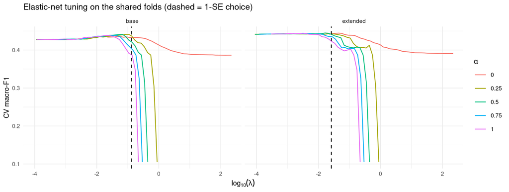

```r
p_tune <- ggplot(grid_summary, aes(x = log10(lambda), y = mean_macro_F1, colour = factor(alpha))) +
  geom_line() + facet_wrap(~ spec) +
  geom_vline(data = bind_rows(lapply(names(sel), function(sp) sel[[sp]]$one_se)),
             aes(xintercept = log10(lambda)), linetype = "dashed") +
  labs(x = expression(log[10](lambda)), y = "CV macro-F1", colour = expression(alpha),
       title = "Elastic-net tuning on the shared folds (dashed = 1-SE choice)") +
  theme_minimal(base_size = 9)
ggsave("results/glmnet_tuning_curve.png", p_tune, width = 9, height = 3.4, dpi = 150)
p_tune
```

```r
lr_models <- cv_summary %>% filter(Model != "Majority class")
final_name <- lr_models$Model[1]
final_spec <- if (grepl("age features", final_name)) "extended" else "base"
final_is_glmnet <- grepl("glmnet", final_name)
final_weighted <- grepl("weights", final_name)
final_alpha <- if (final_is_glmnet) sel[[final_spec]]$one_se$alpha else NA
final_lambda <- if (final_is_glmnet) sel[[final_spec]]$one_se$lambda else NA
```

**Chosen LR model:** M3 glmnet + weights + age features (highest mean CV macro-F1 = 0.441). Tuned values: alpha = 0.5, lambda = 0.02598.

## 4. Final fit, held-out test and interpretation

The chosen model is refit on the full `x_train`/`y_train` and evaluated **once** on `x_test`/`y_test`.

```r
fit_final <- function(xtr, ytr, xnew, mtr, mnew, drop = character(0)) {
  des <- build_design(xtr, xnew, mtr, mnew, final_spec, drop)
  w <- if (final_weighted) class_weights(ytr) else NULL
  if (final_is_glmnet) {
    fit <- glmnet(des$Xtr, ytr, family = "multinomial", type.multinomial = "grouped",
                  alpha = final_alpha, weights = w, lambda = final_lambda)
    prob <- predict(fit, des$Xnew, type = "response")[, , 1]
  } else {
    fit <- fit_multinom(des$Xtr, ytr, w)
    prob <- predict(fit, newdata = data.frame(des$Xnew), type = "probs")
  }
  list(fit = fit, prob = prob, pred = classes[max.col(prob, ties.method = "first")],
       cols = colnames(des$Xtr))
}
final <- fit_final(x_train, y_train, x_test, miss_train, miss_test)
test_m <- class_metrics(y_test, final$pred)

cv_final <- cv_summary %>% filter(Model == final_name)
metrics_out <- bind_rows(
  tibble(Model = final_name, Evaluation = "5-fold CV (mean)", macro_F1 = cv_final$macro_F1,
         balanced_accuracy = cv_final$balanced_accuracy, accuracy = cv_final$accuracy,
         !!!as.list(unlist(cv_final[paste0("recall_", classes)]))),
  tibble(Model = final_name, Evaluation = "Held-out test (20%)", !!!as.list(test_m$summary),
         !!!setNames(as.list(test_m$recall), paste0("recall_", classes))))
write.csv(metrics_out, "results/metrics_summary.csv", row.names = FALSE)
kable(metrics_out, digits = 3, caption = "Final LR model: CV vs held-out test")
```

Final LR model: CV vs held-out test

| Model | Evaluation | macro_F1 | balanced_accuracy | accuracy | recall_Adoption | recall_Transfer | recall_Return | recall_Euthanasia | recall_Other |
| --- | --- | --- | --- | --- | --- | --- | --- | --- | --- |
| M3 glmnet + weights + age features | 5-fold CV (mean) | 0.441 | 0.521 | 0.624 | 0.755 | 0.468 | 0.603 | 0.245 | 0.537 |
| M3 glmnet + weights + age features | Held-out test (20%) | 0.441 | 0.523 | 0.622 | 0.756 | 0.460 | 0.607 | 0.244 | 0.547 |

```r
per_class <- tibble(Class = classes, n_test = as.numeric(table(y_test)),
                    Precision = test_m$precision, Recall = test_m$recall, F1 = test_m$f1)
write.csv(per_class, "results/test_per_class.csv", row.names = FALSE)
kable(per_class, digits = 3, caption = "Per-class test performance")
```

Per-class test performance

| Class | n_test | Precision | Recall | F1 |
| --- | --- | --- | --- | --- |
| Adoption | 1764 | 0.913 | 0.756 | 0.827 |
| Transfer | 1057 | 0.869 | 0.460 | 0.601 |
| Return | 313 | 0.237 | 0.607 | 0.341 |
| Euthanasia | 135 | 0.166 | 0.244 | 0.198 |
| Other | 95 | 0.151 | 0.547 | 0.236 |

```r
write.csv(data.frame(Animal.ID = test_raw$Animal.ID, truth = y_test, pred = final$pred,
                     round(final$prob, 5), check.names = FALSE),
          "results/test_predictions.csv", row.names = FALSE)
```

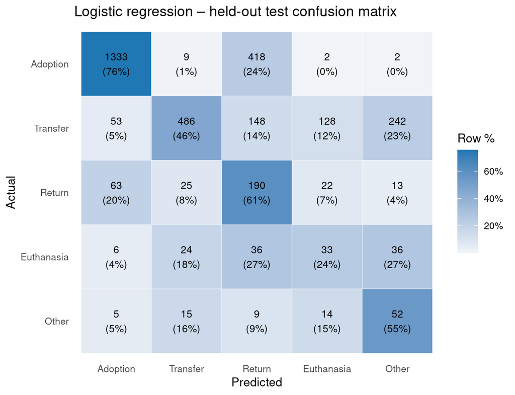

```r
cm_df <- as.data.frame(test_m$cm) %>% group_by(Truth) %>%
  mutate(Row_pct = Freq / sum(Freq)) %>% ungroup()
write.csv(as.data.frame.matrix(test_m$cm), "results/confusion_matrix_test.csv")
p_cm <- ggplot(cm_df, aes(x = Pred, y = forcats::fct_rev(Truth), fill = Row_pct)) +
  geom_tile(colour = "white") +
  geom_text(aes(label = sprintf("%d\n(%.0f%%)", Freq, 100 * Row_pct)), size = 3) +
  scale_fill_gradient(low = "#F0F4F8", high = "#1F78B4", labels = scales::percent) +
  labs(x = "Predicted", y = "Actual", fill = "Row %",
       title = "Logistic regression – held-out test confusion matrix") +
  theme_minimal(base_size = 10) + theme(panel.grid = element_blank())
ggsave("results/confusion_matrix_test.png", p_cm, width = 6, height = 4.6, dpi = 150)
p_cm
```

```r
# Out-of-fold predictions of the chosen model (useful for the group comparison).
oof_df <- bind_rows(lapply(seq_along(cv_data), function(k) {
  d <- cv_data[[k]]
  r <- fit_final(d$x_train, d$y_train, d$x_valid, fold_miss[[k]]$tr, fold_miss[[k]]$va)
  data.frame(train_row = cv_folds[[k]], Animal.ID = train_raw$Animal.ID[cv_folds[[k]]],
             Fold = k, truth = d$y_valid, pred = r$pred, round(r$prob, 5), check.names = FALSE)
})) %>% arrange(train_row)
write.csv(oof_df, "results/cv_oof_predictions.csv", row.names = FALSE)
```

### Coefficients and odds ratios

For explaining effects to stakeholders I use the **unpenalised, unweighted multinomial model on the base features**, fitted on the full training set, with age in years. This gives ordinary odds ratios with Wald 95% CIs, relative to the **Adoption** outcome. (Penalised coefficients are biased towards 1, and weights shift the intercepts.) The selected model’s own coefficients are saved too (`results/final_model_coefficients.csv`).

```r
des_or <- build_design(x_train, x_test, miss_train, miss_test, "base")
X_or <- des_or$Xtr
X_or[, "age_z"] <- x_train$Age_Years_imputed          # odds ratio per year of age
colnames(X_or)[colnames(X_or) == "age_z"] <- "Age_years"
fit_or <- fit_multinom(X_or, y_train)
co <- coef(fit_or); se <- summary(fit_or)$standard.errors
or_tab <- expand.grid(Outcome = rownames(co), Term = colnames(co), stringsAsFactors = FALSE) %>%
  mutate(coef = co[cbind(Outcome, Term)], se = se[cbind(Outcome, Term)],
         OR = exp(coef), OR_low = exp(coef - 1.96 * se), OR_high = exp(coef + 1.96 * se),
         p_value = 2 * pnorm(-abs(coef / se))) %>%
  filter(Term != "(Intercept)") %>% arrange(Outcome, Term)
write.csv(or_tab, "results/odds_ratios_vs_adoption.csv", row.names = FALSE)

# Likelihood-ratio test for dropping each predictor (overall contribution)
drop_lr <- bind_rows(lapply(setdiff(names(x_train), character(0)), function(v) {
  cols <- if (v == "Age_Years_imputed") "Age_years" else grep(paste0("^", make.names(v)), colnames(X_or), value = TRUE)
  f0 <- fit_multinom(X_or[, setdiff(colnames(X_or), cols), drop = FALSE], y_train)
  lr <- deviance(f0) - deviance(fit_or); dfree <- length(cols) * (length(classes) - 1)
  tibble(Predictor = v, LR_chisq = lr, df = dfree, p_value = pchisq(lr, dfree, lower.tail = FALSE))
})) %>% arrange(desc(LR_chisq))
write.csv(drop_lr, "results/drop1_likelihood_ratio.csv", row.names = FALSE)
kable(drop_lr, digits = 3, caption = "Drop-one likelihood-ratio tests (unpenalised multinomial, training set)")
```

Drop-one likelihood-ratio tests (unpenalised multinomial, training set)

| Predictor | LR_chisq | df | p_value |
| --- | --- | --- | --- |
| Spayed.Neutered | 6784.674 | 8 | 0.000 |
| Age_Years_imputed | 790.688 | 4 | 0.000 |
| has_Name | 216.855 | 4 | 0.000 |
| Sex | 139.839 | 8 | 0.000 |
| primary.breed.group | 75.769 | 32 | 0.000 |
| Base_Color | 21.741 | 20 | 0.355 |
| Type | 16.151 | 4 | 0.003 |
| has_pattern | 10.182 | 4 | 0.037 |

```r
if (final_is_glmnet) {
  cf <- coef(final$fit)
  final_coef <- bind_rows(lapply(names(cf), function(cl) tibble(
    Outcome = cl, Term = rownames(cf[[cl]]), coef = as.numeric(cf[[cl]]))))
} else {
  cf <- coef(final$fit)
  final_coef <- as.data.frame(as.table(cf)) %>% rename(Outcome = Var1, Term = Var2, coef = Freq)
}
write.csv(final_coef, "results/final_model_coefficients.csv", row.names = FALSE)
if (final_is_glmnet) {
  zero_terms <- final_coef %>% filter(Term != "(Intercept)") %>% group_by(Term) %>%
    summarise(all_zero = all(coef == 0)) %>% filter(all_zero) %>% pull(Term)
}
```

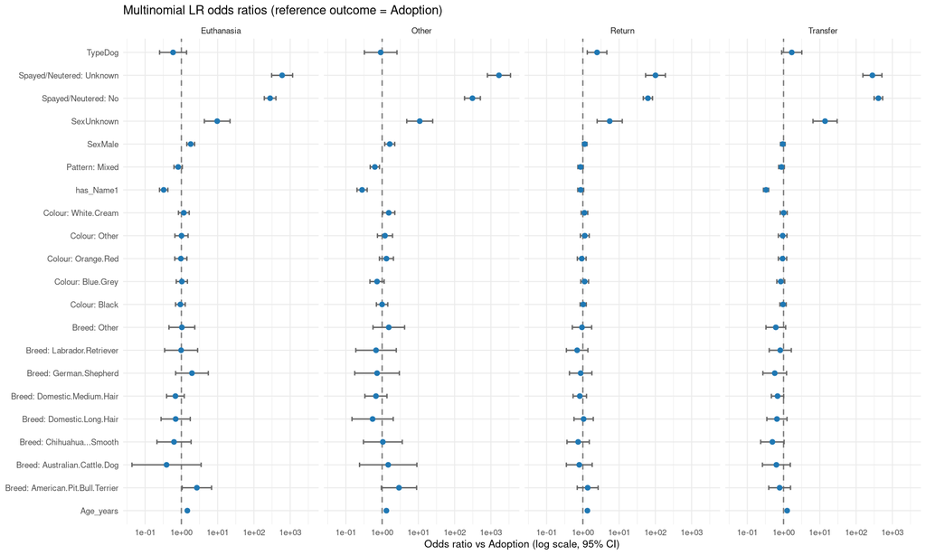

```r
p_or <- or_tab %>%
  mutate(Term = gsub("^primary\\.breed\\.group", "Breed: ", Term),
         Term = gsub("^Base_Color", "Colour: ", Term),
         Term = gsub("^Spayed\\.Neutered", "Spayed/Neutered: ", Term),
         Term = gsub("^has_pattern", "Pattern: ", Term)) %>%
  ggplot(aes(x = OR, y = Term)) +
  geom_vline(xintercept = 1, linetype = "dashed", colour = "grey50") +
  geom_errorbarh(aes(xmin = OR_low, xmax = OR_high), height = 0.2, colour = "grey40") +
  geom_point(size = 1.4, colour = "#1F78B4") +
  scale_x_log10() + facet_wrap(~ Outcome, nrow = 1) +
  labs(x = "Odds ratio vs Adoption (log scale, 95% CI)", y = NULL,
       title = "Multinomial LR odds ratios (reference outcome = Adoption)") +
  theme_minimal(base_size = 8)
ggsave("results/odds_ratios_vs_adoption.png", p_or, width = 10, height = 6, dpi = 150)
p_or
```

```r
key_terms <- c("TypeDog", "Age_years", "has_Name1", "Spayed.NeuteredNo", "Spayed.NeuteredUnknown",
               "SexUnknown", "has_patternMixed")
kable(or_tab %>% filter(Term %in% key_terms) %>%
        transmute(Outcome, Term, OR = sprintf("%.2f (%.2f–%.2f)", OR, OR_low, OR_high)) %>%
        pivot_wider(names_from = Outcome, values_from = OR),
      caption = "Selected odds ratios vs Adoption, OR (95% CI)")
```

Selected odds ratios vs Adoption, OR (95% CI)

| Term | Euthanasia | Other | Return | Transfer |
| --- | --- | --- | --- | --- |
| Age_years | 1.46 (1.41–1.51) | 1.31 (1.25–1.38) | 1.33 (1.30–1.37) | 1.25 (1.22–1.29) |
| SexUnknown | 9.72 (4.31–21.96) | 10.90 (4.78–24.82) | 5.50 (2.48–12.22) | 13.94 (6.48–29.99) |
| Spayed.NeuteredNo | 280.02 (193.43–405.39) | 309.87 (187.49–512.13) | 62.23 (46.40–83.46) | 411.68 (313.65–540.34) |
| Spayed.NeuteredUnknown | 600.66 (308.45–1169.70) | 1669.08 (801.24–3476.92) | 100.78 (53.79–188.80) | 281.69 (153.95–515.45) |
| TypeDog | 0.59 (0.25–1.39) | 0.91 (0.32–2.57) | 2.47 (1.33–4.59) | 1.68 (0.89–3.19) |
| has_Name1 | 0.33 (0.25–0.42) | 0.28 (0.20–0.39) | 0.87 (0.72–1.06) | 0.33 (0.28–0.39) |
| has_patternMixed | 0.81 (0.63–1.06) | 0.63 (0.47–0.85) | 0.87 (0.73–1.03) | 0.88 (0.73–1.05) |

```r
or_of <- function(term, out) sprintf("%.2f", or_tab$OR[or_tab$Term == term & or_tab$Outcome == out])
```

**What this means for shelter staff** (associations, not causal effects; other predictors are held fixed):

- **Age:** each extra year multiplies the odds of Euthanasia rather than Adoption by 1.46, and of Return by 1.33. Older animals are the group that needs early adoption promotion or owner tracing.
- **Name recorded:** having a name cuts the odds of Transfer (vs Adoption) to 0.33 times, and of Euthanasia to 0.33 times. Unnamed animals are a practical flag for early contact with rescue/transfer partners.
- **Spayed/Neutered:** the odds ratios for “No”/“Unknown” vs “Yes” are huge (for example, 411.68 for Transfer). This is too strong to be a believable intake effect. Desexing is usually done before adoption, so this field probably records status at outcome. It is the clearest leakage risk in our shared predictor set (see Section 5).
- **Sex unknown** is linked to non-adoption outcomes (OR 13.94 for Transfer), probably because these are animals processed quickly.
- **Colour and pattern** add little: the drop-one test for `Base_Color` is not significant, and the selected elastic net sets these colour and breed dummies to exactly zero for every outcome: Base_ColorBlack, Base_ColorOrange.Red, Base_ColorOther, primary.breed.groupAustralian.Cattle.Dog, primary.breed.groupDomestic.Long.Hair, primary.breed.groupDomestic.Medium.Hair.

## 5. Sensitivity checks

**(a) Possible leakage in `Spayed.Neutered` and `Name`.** These fields may be recorded at outcome rather than at intake (for example, desexing before adoption, or naming in care). The chosen model is re-run on the same CV folds without them.

**(b) Temporal hold-out.** The A1 marker asked about a temporal split. The shared split is random, which keeps all five models comparable. As an extra check, the same shared rules (steps 8–10 of the template: age medians, top-8 breeds, factor levels) are re-learned on animals whose outcome was before 2026-07-01, and the chosen model (same hyperparameters) is tested on later outcomes.

```r
sens <- list()
for (dr in list(c("Spayed.Neutered"), c("Spayed.Neutered", "has_Name"))) {
  sc <- sapply(seq_along(cv_data), function(k) {
    d <- cv_data[[k]]
    r <- fit_final(d$x_train, d$y_train, d$x_valid, fold_miss[[k]]$tr, fold_miss[[k]]$va, drop = dr)
    class_metrics(d$y_valid, r$pred)$summary
  })
  sens[[length(sens) + 1]] <- tibble(Check = paste("CV without", paste(dr, collapse = " + ")),
                                     !!!as.list(rowMeans(sc)))
}

# Temporal hold-out: replicate the template's training-only rules (steps 8-10).
apply_shared_rules <- function(tr, new) {
  med_all <- median(tr$Age_Years, na.rm = TRUE)
  meds <- tr %>% group_by(Type) %>% summarise(Age_Median = median(Age_Years, na.rm = TRUE), .groups = "drop")
  top8 <- tr %>% filter(Primary.Breed != "Unknown") %>% count(Primary.Breed, name = "Count") %>%
    arrange(desc(Count), Primary.Breed) %>% filter(row_number() <= 8) %>% pull(Primary.Breed)
  f <- function(df) df %>% left_join(meds, by = "Type") %>%
    mutate(Age_Years_imputed = case_when(!is.na(Age_Years) ~ Age_Years, !is.na(Age_Median) ~ Age_Median,
                                         TRUE ~ med_all),
           primary.breed.group = if_else(Primary.Breed %in% top8, Primary.Breed, "Other")) %>%
    select(all_of(model_predictors))
  a <- f(tr); b <- f(new)
  for (v in factor_predictors) { a[[v]] <- factor(a[[v]]); b[[v]] <- factor(b[[v]], levels = levels(a[[v]])) }
  list(x_tr = a, x_new = b)
}
outcome_dt <- as.Date(lubridate::parse_date_time(as.character(data_features$Outcome.Date),
                      orders = c("mdy IMS p", "mdy HMS", "ymd HMS"), locale = "C", tz = "UTC", quiet = TRUE))
stopifnot(!anyNA(outcome_dt))
cut_date <- as.Date("2026-07-01")
tr_t <- data_features[outcome_dt < cut_date, ]; te_t <- data_features[outcome_dt >= cut_date, ]
sr <- apply_shared_rules(tr_t, te_t)
ok <- complete.cases(sr$x_new)
r_t <- fit_final(sr$x_tr, tr_t$Outcome.Group, sr$x_new[ok, ], is.na(tr_t$Age_Years), is.na(te_t$Age_Years)[ok])
m_t <- class_metrics(te_t$Outcome.Group[ok], r_t$pred)
sens[[length(sens) + 1]] <- tibble(Check = sprintf("Temporal hold-out (train n=%d, test n=%d, outcome >= %s)",
                                                   nrow(tr_t), sum(ok), cut_date), !!!as.list(m_t$summary))
sens_tab <- bind_rows(tibble(Check = "Reference: chosen model, held-out test", !!!as.list(test_m$summary)),
                      tibble(Check = "Reference: chosen model, CV", macro_F1 = cv_final$macro_F1,
                             balanced_accuracy = cv_final$balanced_accuracy, accuracy = cv_final$accuracy),
                      bind_rows(sens))
write.csv(sens_tab, "results/sensitivity_checks.csv", row.names = FALSE)
kable(sens_tab, digits = 3, caption = "Sensitivity checks for the chosen LR model")
```

Sensitivity checks for the chosen LR model

| Check | macro_F1 | balanced_accuracy | accuracy |
| --- | --- | --- | --- |
| Reference: chosen model, held-out test | 0.441 | 0.523 | 0.622 |
| Reference: chosen model, CV | 0.441 | 0.521 | 0.624 |
| CV without Spayed.Neutered | 0.369 | 0.438 | 0.496 |
| CV without Spayed.Neutered + has_Name | 0.362 | 0.428 | 0.498 |
| Temporal hold-out (train n=13014, test n=3817, outcome >= 2026-07-01) | 0.415 | 0.504 | 0.616 |

```r
drift <- bind_rows(
  as.data.frame(prop.table(table(tr_t$Outcome.Group))) %>% mutate(Period = "Train (before cut-off)"),
  as.data.frame(prop.table(table(te_t$Outcome.Group))) %>% mutate(Period = "Test (after cut-off)")) %>%
  pivot_wider(names_from = Var1, values_from = Freq)
kable(drift, digits = 3, caption = "Outcome mix before/after the temporal cut-off")
```

Outcome mix before/after the temporal cut-off

| Period | Adoption | Transfer | Return | Euthanasia | Other |
| --- | --- | --- | --- | --- | --- |
| Train (before cut-off) | 0.525 | 0.312 | 0.087 | 0.044 | 0.031 |
| Test (after cut-off) | 0.521 | 0.320 | 0.113 | 0.027 | 0.019 |

Dropping `Spayed.Neutered` lowers CV macro-F1 from 0.441 to 0.369, so much of this model’s signal depends on a field whose intake-time availability is uncertain. The group should decide this jointly, because it affects every model. On the temporal hold-out, macro-F1 is 0.415, slightly below the random-split test. That is a mild drop, consistent with the outcome mix shifting over time.

## 6. Summary

- Chosen model: **M3 glmnet + weights + age features**. CV macro-F1 0.441 (balanced accuracy 0.521). Held-out test macro-F1 0.441, balanced accuracy 0.523, accuracy 0.622.
- Comparison on CV: the unweighted plain LR (M0) gets macro-F1 0.368, and always predicting Adoption gets 0.138.
- Class weighting is what makes LR usable here. Without weights, plain LR mostly predicts Adoption/Transfer and almost never Euthanasia or Other. Adding the age features and the elastic-net penalty gives a further small CV gain, mainly in Return and Euthanasia recall.
- Test recall by class: Adoption 0.76, Transfer 0.46, Return 0.61, Euthanasia 0.24, Other 0.55.